# DAT630 - ASSIGNMENT 1 REPORT

Helge Bjorland

september 2015

The report is min 3, max 8 pages (A4) long, written in English.

# Instructions on how to run code

The python code for task1 can be found in the code folder and is called “main.py”. The code is seperated into functions. To run the code you simply call the main function with parameter 0 or -1.

- With parameter 0 the code will seperate the data into train/test set and evaluate the result.
- With parameter -1 the code will train on all the data, predict using the “adult.test” dataset and write result to “task1.out” file.

Several of the functions used has been adopted from the [tutorial](http://www.onlamp.com/pub/a/python/2006/02/09/ai_decision_trees.html) given in the [practicum 3 session](https://github.com/uis-dat630-fall2015/practicum/tree/master/P03). However, most of the functions have been completely rewritten to fit the dataset and the task. The id3.py file contains the ID3 functions which calculate entropy and gain. These are quite similar to what was given in the example with only minor changes.

# Data exploration

(e.g., summary statistics and/or visualizations of attributes)

```
##       age                    Workclass         fnlwgt
##  Min.   :17.00    Private         :22696   Min.   :  12285
##  1st Qu.:28.00    Self-emp-not-inc: 2541   1st Qu.: 117827
##  Median :37.00    Local-gov       : 2093   Median : 178356
##  Mean   :38.58    ?               : 1836   Mean   : 189778
##  3rd Qu.:48.00    State-gov       : 1298   3rd Qu.: 237051
##  Max.   :90.00    Self-emp-inc    : 1116   Max.   :1484705
##                  (Other)          :  981
##          Education      educationNum                  MartialStatus
##   HS-grad     :10501   Min.   : 1.00    Divorced             : 4443
##   Some-college: 7291   1st Qu.: 9.00    Married-AF-spouse    :   23
##   Bachelors   : 5355   Median :10.00    Married-civ-spouse   :14976
##   Masters     : 1723   Mean   :10.08    Married-spouse-absent:  418
##   Assoc-voc   : 1382   3rd Qu.:12.00    Never-married        :10683
##   11th        : 1175   Max.   :16.00    Separated            : 1025
##  (Other)      : 5134                    Widowed              :  993
##             Occupation            Relationship
##   Prof-specialty :4140    Husband       :13193
##   Craft-repair   :4099    Not-in-family : 8305
##   Exec-managerial:4066    Other-relative:  981
##   Adm-clerical   :3770    Own-child     : 5068
##   Sales          :3650    Unmarried     : 3446
##   Other-service  :3295    Wife          : 1568
##  (Other)         :9541
##                   Race            Sex         capitalGain
##   Amer-Indian-Eskimo:  311    Female:10771   Min.   :    0
##   Asian-Pac-Islander: 1039    Male  :21790   1st Qu.:    0
##   Black             : 3124                   Median :    0
##   Other             :  271                   Mean   : 1078
##   White             :27816                   3rd Qu.:    0
##                                              Max.   :99999
##
##   capitalLoss      hoursPERweek             Country         Target
##  Min.   :   0.0   Min.   : 1.00    United-States:29170    <=50K:24720
##  1st Qu.:   0.0   1st Qu.:40.00    Mexico       :  643    >50K : 7841
##  Median :   0.0   Median :40.00    ?            :  583
##  Mean   :  87.3   Mean   :40.44    Philippines  :  198
##  3rd Qu.:   0.0   3rd Qu.:45.00    Germany      :  137
##  Max.   :4356.0   Max.   :99.00    Canada       :  121
##                                   (Other)       : 1709
```

From this initial summary statistic we notice some very obvious facts. There are about twice the amount of male as female, and mostly White people located in the US. The Capital-gain and Capital-loss seems to have large spread but not very much variance. There are some missing values denoted by ?. The main observations are “<=50K” with about 76%. After reading the description for “fnlwgt” this variable seems to be used in a weight of demographic characteristic within each state. We can continue exploring the data with some simple pre-processing techniques.

```r
nearZeroVar(training, saveMetrics= TRUE)
```

```
##                freqRatio percentUnique zeroVar   nzv
## age             1.011261   0.224194589   FALSE FALSE
## Workclass       8.931917   0.027640429   FALSE FALSE
## fnlwgt          1.000000  66.484444581   FALSE FALSE
## Education       1.440269   0.049138540   FALSE FALSE
## educationNum    1.440269   0.049138540   FALSE FALSE
## MartialStatus   1.401853   0.021498111   FALSE FALSE
## Occupation      1.010002   0.046067381   FALSE FALSE
## Relationship    1.588561   0.018426952   FALSE FALSE
## Race            8.903969   0.015355794   FALSE FALSE
## Sex             2.023025   0.006142317   FALSE FALSE
## capitalGain    86.020173   0.365467891   FALSE  TRUE
## capitalLoss   153.673267   0.282546605   FALSE  TRUE
## hoursPERweek    5.398013   0.288688922   FALSE FALSE
## Country        45.365474   0.128988667   FALSE  TRUE
## Target          3.152659   0.006142317   FALSE FALSE
```

```r
descrCor <- cor(training[,c("age", "fnlwgt", "educationNum", "capitalGain", "capitalLoss", "hoursPERweek")])
# Find correlated continous variables:
findCorrelation(descrCor, cutoff = .75)
```

```
## integer(0)
```

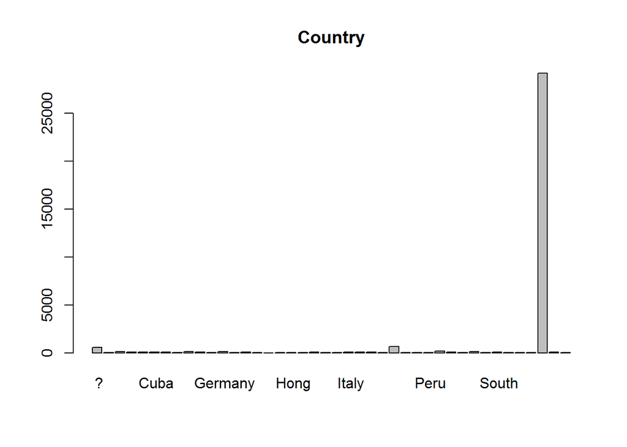

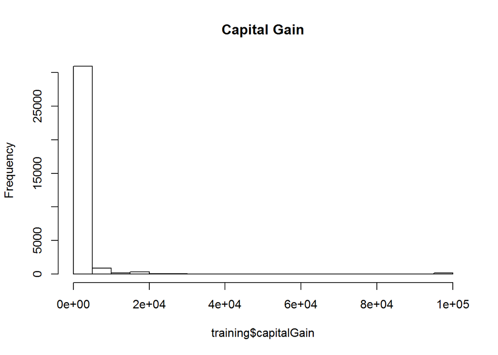

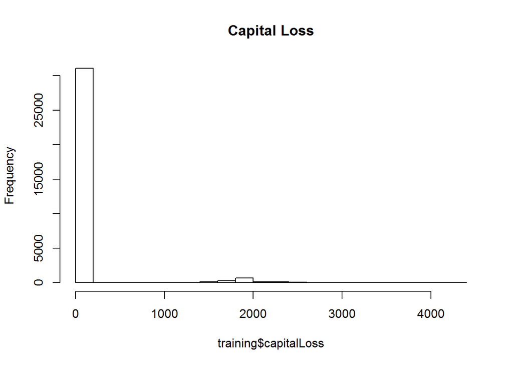

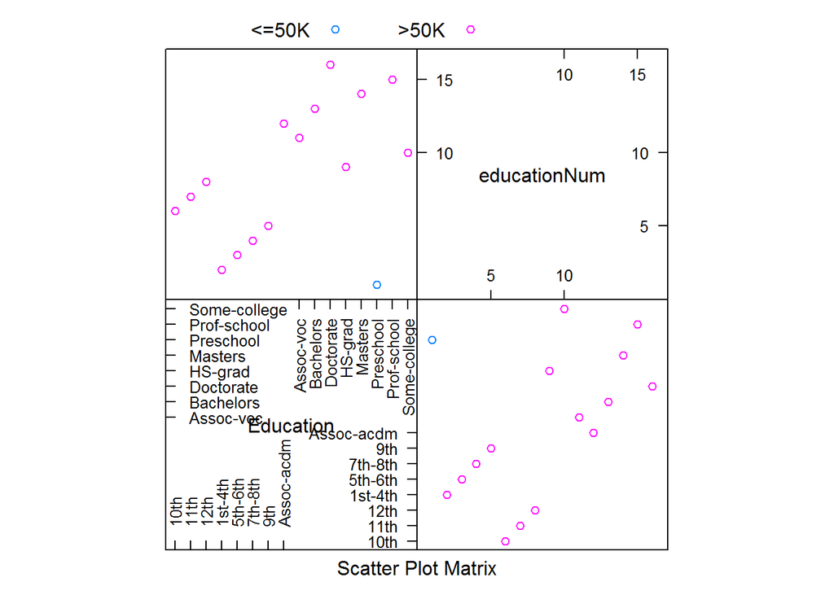

The last graph show how similar education and education-num are. From the litterature we know that education-num is a numeric representation of education. We can check this by running a simple linear regression between the variables. The result from this regression test can be seen in Appendix A. We see that the R2 is 1 with extremely low p-value which supports the theory that the variables perfectly explain each other. After analysing Marital Status it seems like much of this information is also contained in the Relationship variable.

# Data processing steps applied

(e.g., variable transformations, feature creation)

I started by testing my decision tree by just removing all continous variables. This actually got a quite high in sample accuracy of about 82% which would probably be somewhat lower out of sample.

After doing the analysis above and reading [“Predicting earning potential on adult dataset”](http://www.dataminingmasters.com/uploads/studentProjects/Earning_potential_report.pdf) I chose to remove * Country, * fnlwgt, * educationNum, * MartialStatus

In order to get the decision tree to work I also had to use discretization to change the continous variables. I choose to use the same bins as Type A from the paper mentioned above. * hoursPERweek: 2 bins * age: 11 bins * capitalGain: 1500 bins * capitalLoss: 500 bins

I chos to leave all missing values since decision trees usually can handle this well (when it’s represented as a symbol).

With these transformations the model achieved a better in sample accuracy of about 84%.

# Evaluation

Looking at the first 3 levels of the decision tree, it seems that capitalGain, age and capitalLoss are the most important. It says that if you have a capitalGain of above 5119 then you earn more than 50K. Else, if you are above 30years and had a capitalLoss larger than 1820 then you also earn more than 50K. Otherwise you earn less than 50K. The majority in this first level earns less than 50K.

The 3 most important attributes are age, capitalGain and hoursPERweek. The others can be seen from the graph below.

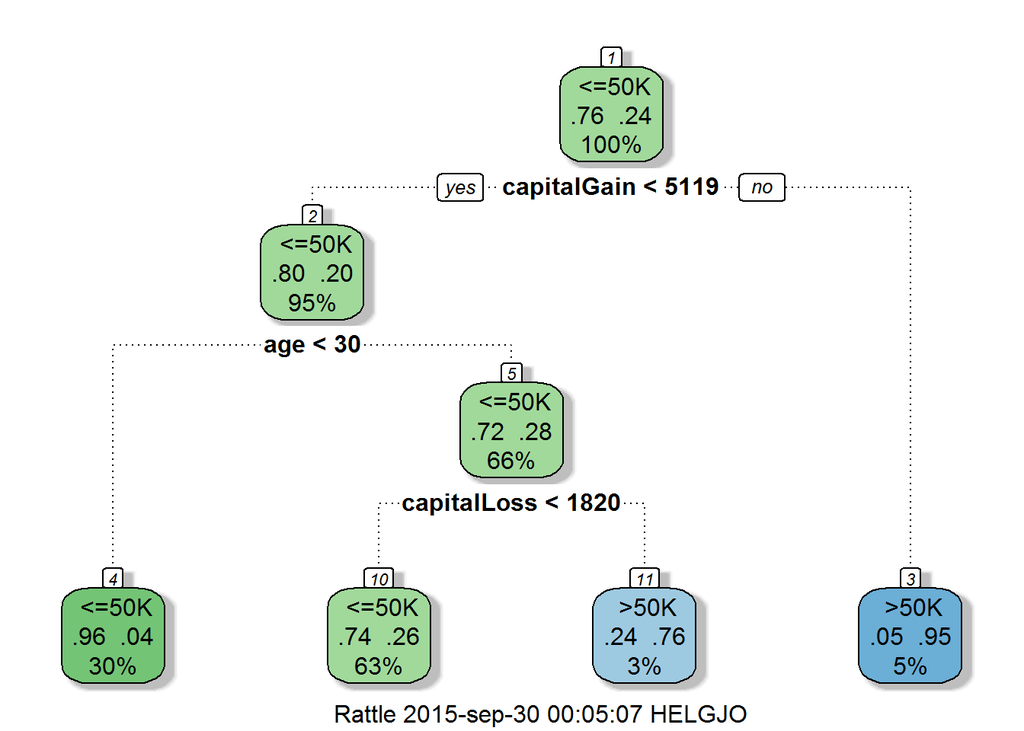

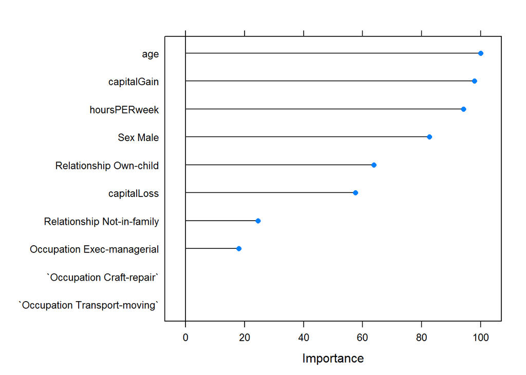

# Appendix A: Education variable correlation

```
##
## Call:
## lm(formula = .outcome ~ ., data = dat)
##
## Residuals:
##        Min         1Q     Median         3Q        Max
## -9.845e-11 -2.000e-14  0.000e+00  1.000e-14  4.583e-10
##
## Coefficients: (1 not defined because of singularities)
##                                  Estimate Std. Error    t value Pr(>|t|)
## (Intercept)                     6.000e+00  9.270e-14  6.472e+13   <2e-16
## `\\`(Intercept)\\``                    NA         NA         NA       NA
## `\\`education 11th\\``          1.000e+00  1.242e-13  8.054e+12   <2e-16
## `\\`education 12th\\``          2.000e+00  1.647e-13  1.215e+13   <2e-16
## `\\`education 1st-4th\\``      -4.000e+00  2.373e-13 -1.686e+13   <2e-16
## `\\`education 5th-6th\\``      -3.000e+00  1.808e-13 -1.660e+13   <2e-16
## `\\`education 7th-8th\\``      -2.000e+00  1.449e-13 -1.380e+13   <2e-16
## `\\`education 9th\\``          -1.000e+00  1.555e-13 -6.429e+12   <2e-16
## `\\`education Assoc-acdm\\``    6.000e+00  1.269e-13  4.728e+13   <2e-16
## `\\`education Assoc-voc\\``     5.000e+00  1.200e-13  4.167e+13   <2e-16
## `\\`education Bachelors\\``     7.000e+00  1.005e-13  6.969e+13   <2e-16
## `\\`education Doctorate\\``     1.000e+01  1.673e-13  5.975e+13   <2e-16
## `\\`education HS-grad\\``       3.000e+00  9.673e-14  3.101e+13   <2e-16
## `\\`education Masters\\``       8.000e+00  1.151e-13  6.951e+13   <2e-16
## `\\`education Preschool\\``    -5.000e+00  4.072e-13 -1.228e+13   <2e-16
## `\\`education Prof-school\\``   9.000e+00  1.500e-13  5.998e+13   <2e-16
## `\\`education Some-college\\``  4.000e+00  9.845e-14  4.063e+13   <2e-16
##
## (Intercept)                    ***
## `\\`(Intercept)\\``
## `\\`education 11th\\``         ***
## `\\`education 12th\\``         ***
## `\\`education 1st-4th\\``      ***
## `\\`education 5th-6th\\``      ***
## `\\`education 7th-8th\\``      ***
## `\\`education 9th\\``          ***
## `\\`education Assoc-acdm\\``   ***
## `\\`education Assoc-voc\\``    ***
## `\\`education Bachelors\\``    ***
## `\\`education Doctorate\\``    ***
## `\\`education HS-grad\\``      ***
## `\\`education Masters\\``      ***
## `\\`education Preschool\\``    ***
## `\\`education Prof-school\\``  ***
## `\\`education Some-college\\`` ***
## ---
## Signif. codes:  0 '***' 0.001 '**' 0.01 '*' 0.05 '.' 0.1 ' ' 1
##
## Residual standard error: 2.832e-12 on 32545 degrees of freedom
## Multiple R-squared:      1,  Adjusted R-squared:      1
## F-statistic: 1.792e+27 on 15 and 32545 DF,  p-value: < 2.2e-16
```

# Appendix B: Decision tree with no preprocessing

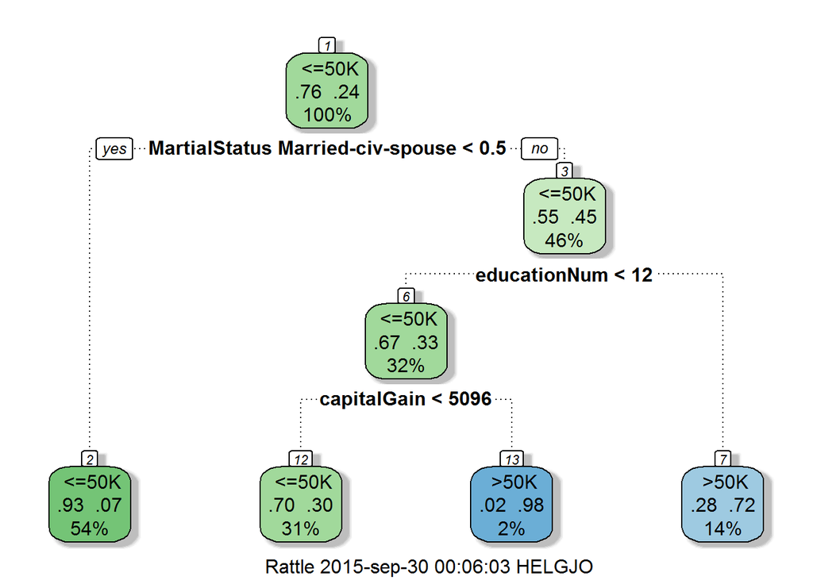

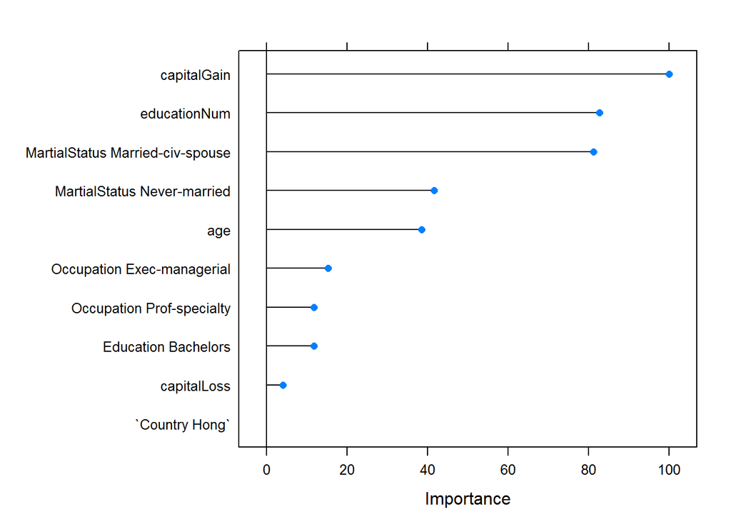